# PRAK SESI UTS’

Adisti Suci Rahmah

2023-09-04

```r
library("forecast")
```

```r
library("graphics")
library("TTR")
library("TSA")
library("rio")
data1 <- import("https://raw.githubusercontent.com/adistisucirahmah/mpdw/main/praktikum/datahujan.csv")
data1
```

```
##       month total_rainfall
## 1   2001-01          425.8
## 2   2001-02           86.6
## 3   2001-03          297.3
## 4   2001-04          203.3
## 5   2001-05          164.9
## 6   2001-06          137.1
## 7   2001-07          111.3
## 8   2001-08          158.3
## 9   2001-09          162.0
## 10  2001-10          252.2
## 11  2001-11          175.3
## 12  2001-12          609.0
## 13  2002-01          221.2
## 14  2002-02           50.8
```

[output cut: 221 more lines]

```r
## Eksplorasi Data

View(data1)
str(data1)
```

```
## 'data.frame':    235 obs. of  2 variables:
##  $ month         : chr  "2001-01" "2001-02" "2001-03" "2001-04" ...
##  $ total_rainfall: num  425.8 86.6 297.3 203.3 164.9 ...
```

```r
dim(data1)
```

```
## [1] 235   2
```

```r
##Mengubah data agar terbaca sebagai data deret waktu dengan fungsi `ts()` .

data1.ts <- ts(data1$total_rainfall)
data1.ts
```

```
## Time Series:
## Start = 1
## End = 235
## Frequency = 1
##   [1] 425.8  86.6 297.3 203.3 164.9 137.1 111.3 158.3 162.0 252.2 175.3 609.0
##  [13] 221.2  50.8  55.6 116.5 236.6  83.1 233.7  54.2 124.2  10.8 307.2 255.0
##  [25] 444.2 172.9 154.6 159.9  81.8  50.3 170.4 193.6 205.3 351.4 133.8 273.0
##  [37] 600.9  31.9 269.4  57.1 137.6 127.2 166.6 185.2 128.9 125.6 166.2 139.8
##  [49] 163.2   8.4  82.4  81.7 331.1  82.3 104.0  58.5 175.7 314.5 362.9 166.0
##  [61] 454.4 115.5  83.1 239.8 205.7 236.8 153.8 127.3  83.3 102.0 185.6 765.9
##  [73] 450.1 105.5 269.1 240.2 127.2 139.0 141.7 190.7 149.0 237.2 367.9 468.6
##  [85] 262.6 129.2 294.1  87.2 124.9 118.3  89.1 327.3 164.4 159.5 324.3 244.2
##  [97]  38.3 201.8 223.3 183.7 198.6  21.8 161.0 177.8 109.6 133.4 281.8 189.8
## [109]  69.5   6.3 238.0 158.5 157.5 240.5 298.5 158.4 121.5 166.2 278.8 181.4
## [121] 513.2  23.0 256.6 217.8 127.0 213.0  76.6  81.4 136.4 216.8 377.8 284.6
## [133] 106.1  83.6 313.4 260.6 292.0  53.0 130.8 119.0 107.6 122.2 208.2 363.4
## [145] 262.0 395.2  85.8 159.4 211.4 111.4 174.6 165.6 257.0 285.4 292.4 348.2
## [157]  75.4   0.2  66.0 110.0 125.8  71.4 148.6 241.0  83.6 120.0 250.8 245.6
## [169]  79.6  18.8  84.4  73.2  89.0  95.8 116.8 185.8  61.6  87.2  72.6 302.3
## [181] 126.6 186.0   6.2  89.8 193.8 162.8 168.6 139.2 118.9 181.0 290.2 292.6
## [193] 197.6 158.4 136.2 208.6 190.0 106.0  79.6  84.2 124.4 120.8 268.6 371.2
## [205] 287.0  14.8  44.6  61.2 132.2 182.6 143.2 121.6 144.4 234.4 169.6 172.6
## [217]  63.6  31.6  72.2 174.8  69.0 173.8  12.2  11.8  22.8 176.8 137.4 421.5
## [229]  88.4  65.0 108.8 188.0 255.6 233.8 140.8
```

```r
##Menampilkan ringkasan data

summary(data1.ts)
```

```
##    Min. 1st Qu.  Median    Mean 3rd Qu.    Max.
##     0.2    98.9   158.5   175.9   236.7   765.9
```

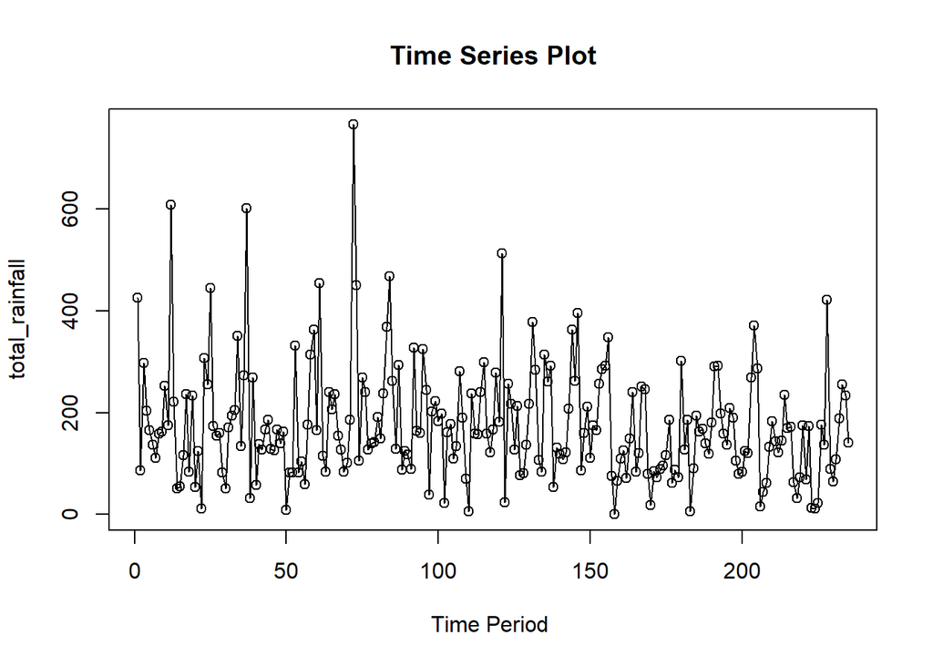

```r
###Membuat plot data deret waktu

ts.plot(data1.ts, xlab="Time Period ", ylab="total_rainfall",
        main = "Time Series Plot")
points(data1.ts)
```

```r
#menyimpan plot
#dev.copy(png, "eksplorasi.png")
#dev.off()
```

## Single Exponential Smoothing & Double Exponential Smoothing

Metode *Exponential Smoothing* adalah metode pemulusan dengan melakukan pembobotan menurun secara eksponensial. Nilai yang lebih baru diberi bobot yang lebih besar dari nilai terdahulu. Terdapat satu atau lebih parameter pemulusan yang ditentukan secara eksplisit, dan hasil pemilihan parameter tersebut akan menentukan bobot yang akan diberikan pada nilai pengamatan. Ada dua macam model, yaitu model tunggal dan ganda.

### Pembagian Data

Pembagian data latih dan data uji dilakukan dengan perbandingan 80% data latih dan 20% data uji.

```r
#membagi training dan testing
training<-data1[1:188,]
training
```

```
##       month total_rainfall
## 1   2001-01          425.8
## 2   2001-02           86.6
## 3   2001-03          297.3
## 4   2001-04          203.3
## 5   2001-05          164.9
## 6   2001-06          137.1
## 7   2001-07          111.3
## 8   2001-08          158.3
## 9   2001-09          162.0
## 10  2001-10          252.2
## 11  2001-11          175.3
## 12  2001-12          609.0
## 13  2002-01          221.2
## 14  2002-02           50.8
```

[output cut: 174 more lines]

```r
testing<-data1[189:235,]
testing
```

```
##       month total_rainfall
## 189 2016-09          118.9
## 190 2016-10          181.0
## 191 2016-11          290.2
## 192 2016-12          292.6
## 193 2017-01          197.6
## 194 2017-02          158.4
## 195 2017-03          136.2
## 196 2017-04          208.6
## 197 2017-05          190.0
## 198 2017-06          106.0
## 199 2017-07           79.6
## 200 2017-08           84.2
## 201 2017-09          124.4
## 202 2017-10          120.8
```

[output cut: 33 more lines]

```r
train.ts <- ts(training$total_rainfall)
train.ts
```

```
## Time Series:
## Start = 1
## End = 188
## Frequency = 1
##   [1] 425.8  86.6 297.3 203.3 164.9 137.1 111.3 158.3 162.0 252.2 175.3 609.0
##  [13] 221.2  50.8  55.6 116.5 236.6  83.1 233.7  54.2 124.2  10.8 307.2 255.0
##  [25] 444.2 172.9 154.6 159.9  81.8  50.3 170.4 193.6 205.3 351.4 133.8 273.0
##  [37] 600.9  31.9 269.4  57.1 137.6 127.2 166.6 185.2 128.9 125.6 166.2 139.8
##  [49] 163.2   8.4  82.4  81.7 331.1  82.3 104.0  58.5 175.7 314.5 362.9 166.0
##  [61] 454.4 115.5  83.1 239.8 205.7 236.8 153.8 127.3  83.3 102.0 185.6 765.9
##  [73] 450.1 105.5 269.1 240.2 127.2 139.0 141.7 190.7 149.0 237.2 367.9 468.6
##  [85] 262.6 129.2 294.1  87.2 124.9 118.3  89.1 327.3 164.4 159.5 324.3 244.2
##  [97]  38.3 201.8 223.3 183.7 198.6  21.8 161.0 177.8 109.6 133.4 281.8 189.8
## [109]  69.5   6.3 238.0 158.5 157.5 240.5 298.5 158.4 121.5 166.2 278.8 181.4
## [121] 513.2  23.0 256.6 217.8 127.0 213.0  76.6  81.4 136.4 216.8 377.8 284.6
## [133] 106.1  83.6 313.4 260.6 292.0  53.0 130.8 119.0 107.6 122.2 208.2 363.4
## [145] 262.0 395.2  85.8 159.4 211.4 111.4 174.6 165.6 257.0 285.4 292.4 348.2
## [157]  75.4   0.2  66.0 110.0 125.8  71.4 148.6 241.0  83.6 120.0 250.8 245.6
## [169]  79.6  18.8  84.4  73.2  89.0  95.8 116.8 185.8  61.6  87.2  72.6 302.3
## [181] 126.6 186.0   6.2  89.8 193.8 162.8 168.6 139.2
```

```r
test.ts <- ts(testing$total_rainfall)
test.ts
```

```
## Time Series:
## Start = 1
## End = 47
## Frequency = 1
##  [1] 118.9 181.0 290.2 292.6 197.6 158.4 136.2 208.6 190.0 106.0  79.6  84.2
## [13] 124.4 120.8 268.6 371.2 287.0  14.8  44.6  61.2 132.2 182.6 143.2 121.6
## [25] 144.4 234.4 169.6 172.6  63.6  31.6  72.2 174.8  69.0 173.8  12.2  11.8
## [37]  22.8 176.8 137.4 421.5  88.4  65.0 108.8 188.0 255.6 233.8 140.8
```

### Eksplorasi

Eksplorasi dilakukan dengan membuat plot data deret waktu untuk keseluruhan data, data latih, dan data uji.

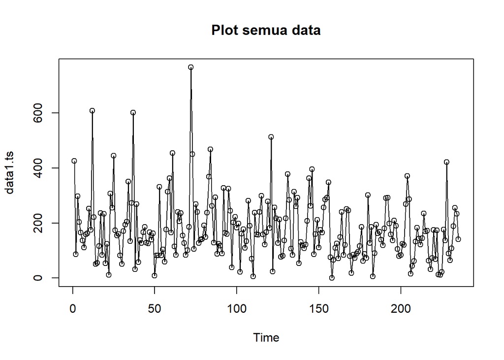

```r
#eksplorasi data
plot(data1.ts, col="black",main="Plot semua data")
points(data1.ts)
```

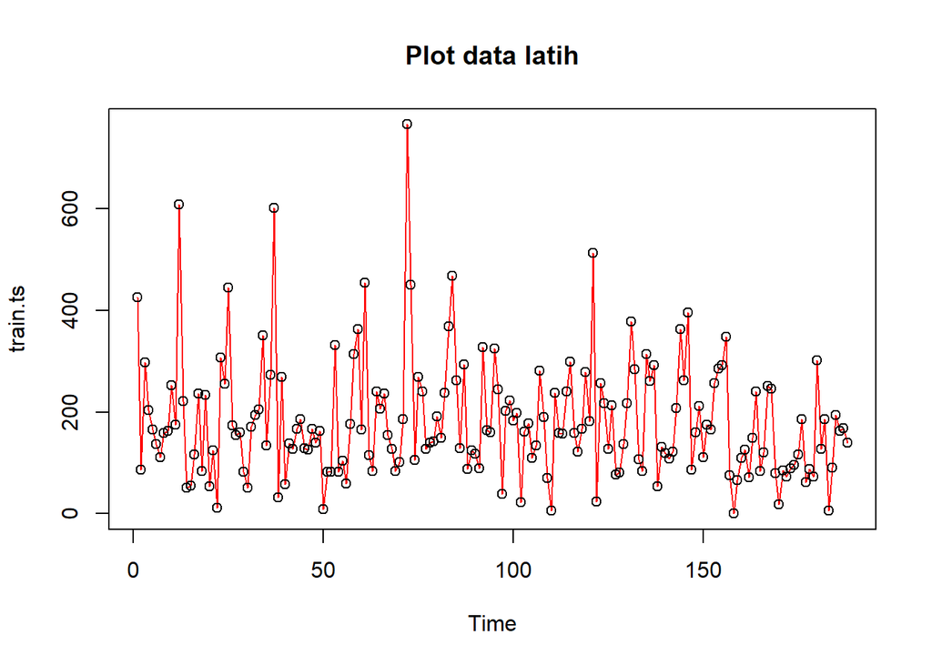

```r
plot(train.ts, col="red",main="Plot data latih")
points(train.ts)
```

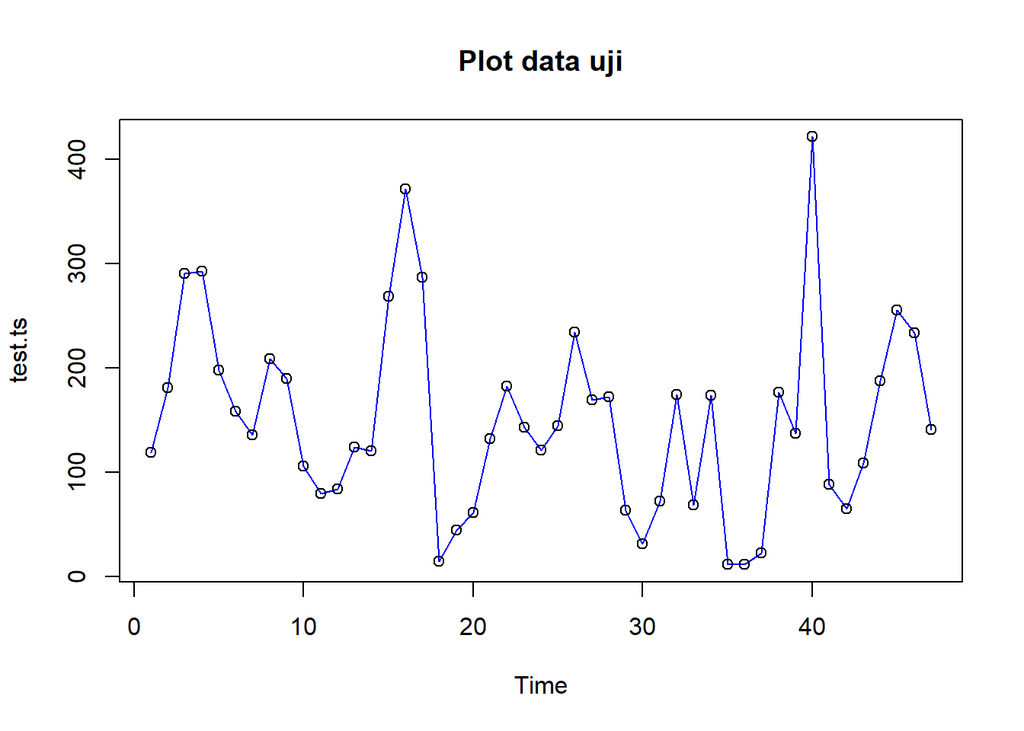

```r
plot(test.ts, col="blue",main="Plot data uji")
points(test.ts)
```

### SES

Single Exponential Smoothing merupakan metode pemulusan yang tepat digunakan untuk data dengan pola stasioner atau konstan.

Nilai pemulusan pada periode ke-t didapat dari persamaan:

$$\tilde{y}_T=\lambda y_t+(1-\lambda)\tilde{y}_{T-1}$$

Nilai parameter $\lambda$ adalah nilai antara 0 dan 1.

Nilai pemulusan periode ke-t bertindak sebagai nilai ramalan pada periode ke-$(T+\tau)$.

$$\tilde{y}_{T+\tau}(T)=\tilde{y}_T$$

Pemulusan dengan metode SES dapat dilakukan dengan dua fungsi dari *packages* berbeda, yaitu (1) fungsi `ses()` dari *packages* `forecast` dan (2) fungsi `HoltWinters` dari *packages* `stats` .

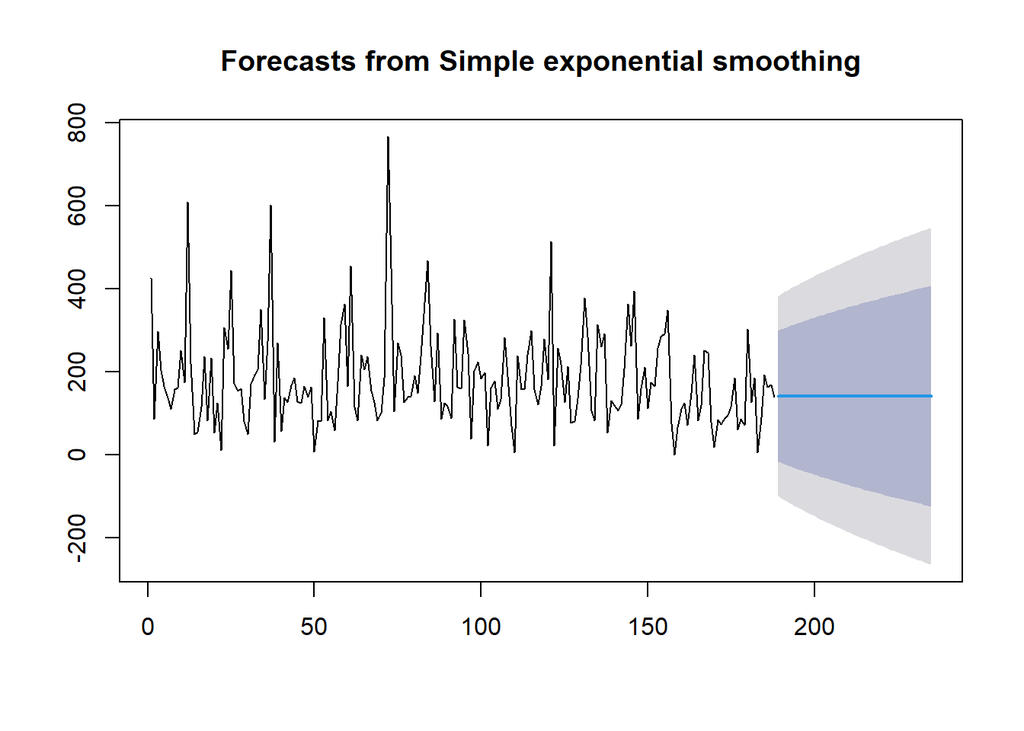

```r
#Cara 1 (fungsi ses)
ses.1 <- ses(train.ts, h = 47, alpha = 0.2)
plot(ses.1)
```

```r
ses.1
```

```
##     Point Forecast      Lo 80    Hi 80      Lo 95    Hi 95
## 189       141.7708  -15.62893 299.1706  -98.95133 382.4930
## 190       141.7708  -18.74606 302.2877 -103.71857 387.2602
## 191       141.7708  -21.80380 305.3455 -108.39498 391.9367
## 192       141.7708  -24.80542 308.3471 -112.98556 396.5272
## 193       141.7708  -27.75390 311.2956 -117.49488 401.0365
## 194       141.7708  -30.65197 314.1936 -121.92709 405.4688
## 195       141.7708  -33.50213 317.0438 -126.28603 409.8277
## 196       141.7708  -36.30667 319.8483 -130.57521 414.1169
## 197       141.7708  -39.06773 322.6094 -134.79788 418.3396
## 198       141.7708  -41.78726 325.3289 -138.95704 422.4987
## 199       141.7708  -44.46708 328.0088 -143.05548 426.5971
## 200       141.7708  -47.10888 330.6506 -147.09577 430.6374
## 201       141.7708  -49.71424 333.2559 -151.08032 434.6220
## 202       141.7708  -52.28463 335.8263 -155.01139 438.5531
```

[output cut: 33 more lines]

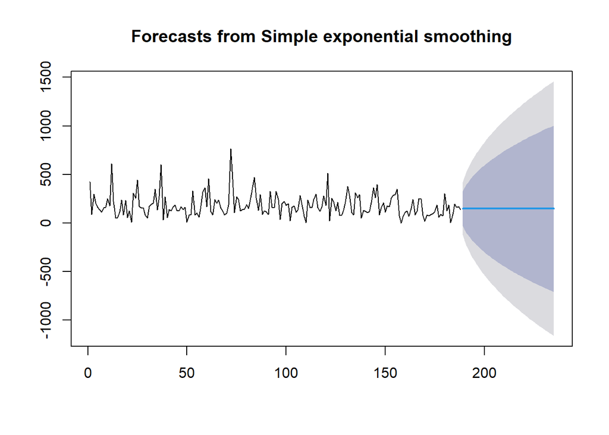

```r
ses.2<- ses(train.ts, h = 47, alpha = 0.7)
plot(ses.2)
```

```r
ses.2
```

```
##     Point Forecast      Lo 80     Hi 80      Lo 95     Hi 95
## 189       147.4146  -29.14457  323.9738  -122.6094  417.4386
## 190       147.4146  -68.10335  362.9326  -182.1917  477.0209
## 191       147.4146 -101.02619  395.8555  -232.5428  527.3721
## 192       147.4146 -130.06994  424.8992  -276.9614  571.7907
## 193       147.4146 -156.34932  451.1786  -317.1522  611.9815
## 194       147.4146 -180.52954  475.3588  -354.1327  648.9620
## 195       147.4146 -203.04539  497.8747  -388.5677  683.3970
## 196       147.4146 -224.19951  519.0288  -420.9202  715.7494
## 197       147.4146 -244.21264  539.0419  -451.5276  746.3569
## 198       147.4146 -263.25161  558.0809  -480.6452  775.4745
## 199       147.4146 -281.44620  576.2755  -508.4714  803.3007
## 200       147.4146 -298.89967  593.7289  -535.1642  829.9935
## 201       147.4146 -315.69583  610.5251  -560.8517  855.6810
## 202       147.4146 -331.90379  626.7331  -585.6396  880.4689
```

[output cut: 33 more lines]

Untuk mendapatkan gambar hasil pemulusan pada data latih dengan fungsi `ses()` , perlu digunakan fungsi `autoplot()` dan `autolayer()` dari *library packages* `ggplot2` .

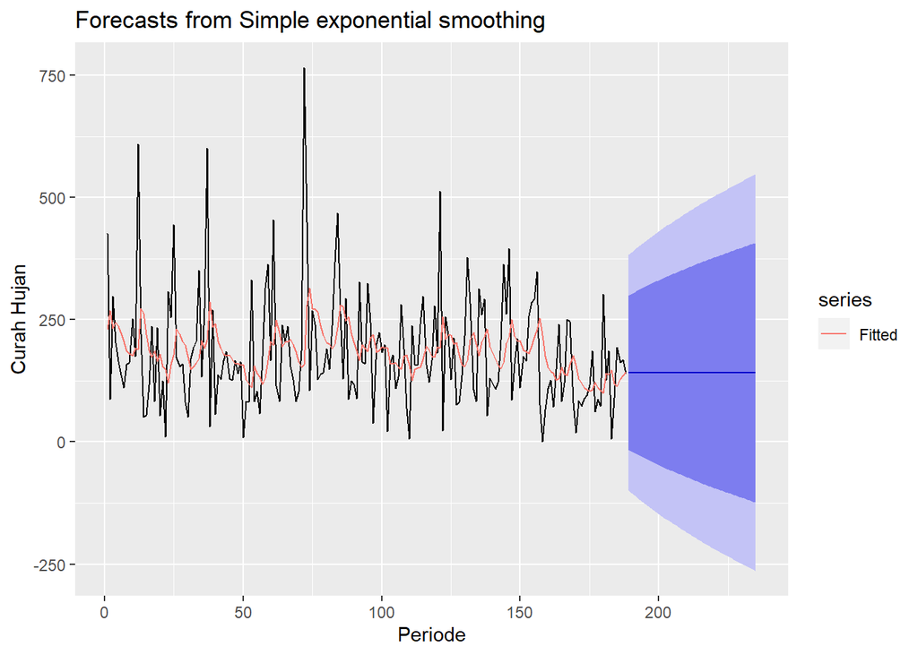

```r
library(ggplot2)
autoplot(ses.1) +
  autolayer(fitted(ses.1), series="Fitted") +
  ylab("Curah Hujan") + xlab("Periode")
```

Pada fungsi `ses()` , terdapat beberapa argumen yang umum digunakan, yaitu nilia `y` , `gamma` , `beta` , `alpha` , dan `h` .

Nilai `y` adalah nilai data deret waktu, `gamma` adalah parameter pemulusan untuk komponen musiman, `beta` adalah parameter pemulusan untuk tren, dan `alpha` adalah parameter pemulusan untuk stasioner, serta `h` adalah banyaknya periode yang akan diramalkan.

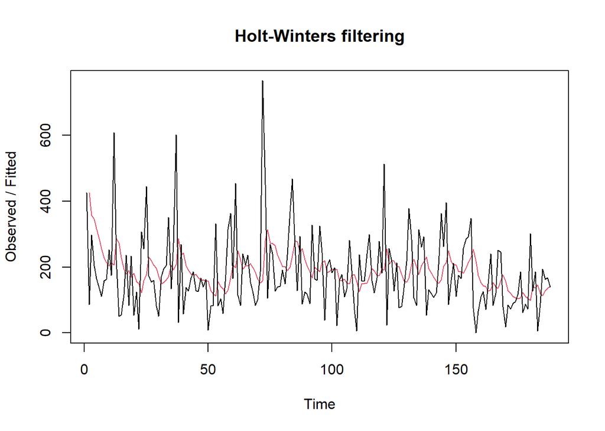

```r
#Cara 2 (fungsi Holtwinter)
ses1<- HoltWinters(train.ts, gamma = FALSE, beta = FALSE, alpha = 0.2)
plot(ses1)
```

```r
#ramalan
ramalan1<- forecast(ses1, h=47)
ramalan1
```

```
##     Point Forecast      Lo 80    Hi 80     Lo 95    Hi 95
## 189       141.7708  -18.32117 301.8628 -103.0688 386.6104
## 190       141.7708  -21.49161 305.0333 -107.9175 391.4592
## 191       141.7708  -24.60165 308.1433 -112.6739 396.2156
## 192       141.7708  -27.65461 311.1963 -117.3430 400.8847
## 193       141.7708  -30.65353 314.1952 -121.9295 405.4711
## 194       141.7708  -33.60117 317.1428 -126.4375 409.9792
## 195       141.7708  -36.50007 320.0417 -130.8710 414.4127
## 196       141.7708  -39.35259 322.8943 -135.2335 418.7752
## 197       141.7708  -42.16087 325.7025 -139.5284 423.0701
## 198       141.7708  -44.92692 328.4686 -143.7587 427.3004
## 199       141.7708  -47.65258 331.1942 -147.9273 431.4689
## 200       141.7708  -50.33957 333.8812 -152.0367 435.5783
## 201       141.7708  -52.98949 336.5312 -156.0894 439.6311
## 202       141.7708  -55.60384 339.1455 -160.0877 443.6294
```

[output cut: 33 more lines]

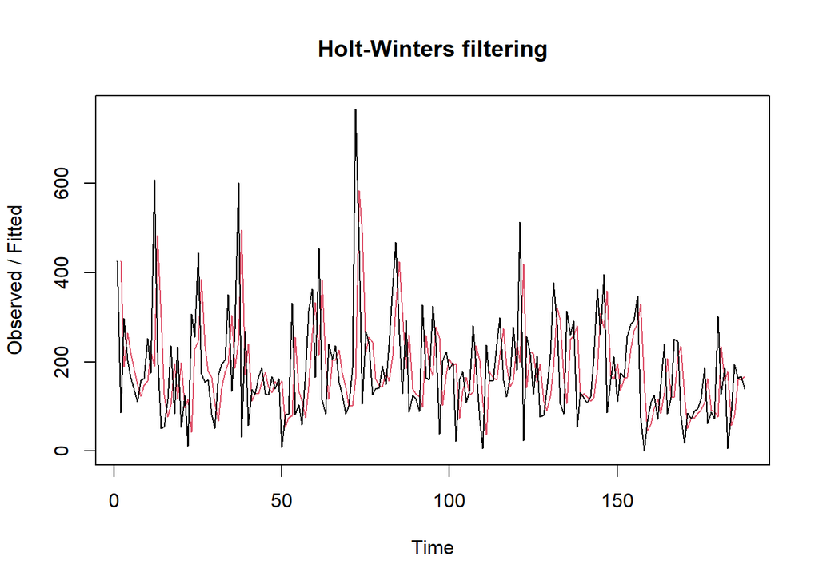

```r
ses2<- HoltWinters(train.ts, gamma = FALSE, beta = FALSE, alpha = 0.7)
plot(ses2)
```

```r
#ramalan
ramalan2<- forecast(ses2, h=47)
ramalan2
```

```
##     Point Forecast      Lo 80     Hi 80      Lo 95     Hi 95
## 189       147.4146  -29.32524  324.1545  -122.8857  417.7150
## 190       147.4146  -68.32388  363.1532  -182.5290  477.3582
## 191       147.4146 -101.28042  396.1097  -232.9316  527.7609
## 192       147.4146 -130.35389  425.1832  -277.3957  572.2249
## 193       147.4146 -156.66015  451.4894  -317.6276  612.4569
## 194       147.4146 -180.86512  475.6944  -354.6459  649.4752
## 195       147.4146 -203.40401  498.2333  -389.1162  683.9455
## 196       147.4146 -224.57978  519.4090  -421.5017  716.3310
## 197       147.4146 -244.61338  539.4427  -452.1405  746.9697
## 198       147.4146 -263.67184  558.5011  -481.2879  776.1171
## 199       147.4146 -281.88504  576.7143  -509.1426  803.9718
## 200       147.4146 -299.35637  594.1856  -535.8627  830.6919
## 201       147.4146 -316.16972  610.9990  -561.5765  856.4057
## 202       147.4146 -332.39426  627.2235  -586.3897  881.2190
```

[output cut: 33 more lines]

Fungsi `HoltWinters` memiliki argumen yang sama dengan fungsi `ses()` . Argumen-argumen kedua fungsi dapat dilihat lebih lanjut dengan `?ses()` atau `?HoltWinters` .

Nilai parameter $\alpha$ dari kedua fungsi dapat dioptimalkan menyesuaikan dari *error*-nya paling minimumnya. Caranya adalah dengan membuat parameter $\alpha =$ `NULL` .

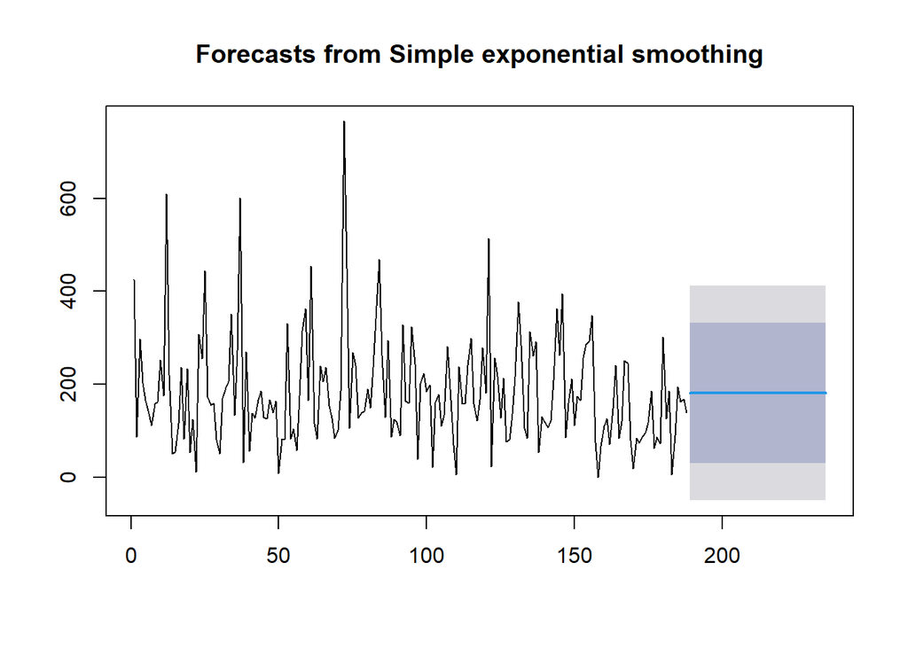

```r
#SES
ses.opt <- ses(train.ts, h = 47, alpha = NULL)
plot(ses.opt)
```

```r
ses.opt
```

```
##     Point Forecast    Lo 80    Hi 80     Lo 95    Hi 95
## 189       180.9405 30.03004 331.8509 -49.85712 411.7381
## 190       180.9405 30.03004 331.8509 -49.85712 411.7381
## 191       180.9405 30.03004 331.8509 -49.85713 411.7381
## 192       180.9405 30.03004 331.8509 -49.85713 411.7381
## 193       180.9405 30.03004 331.8509 -49.85713 411.7381
## 194       180.9405 30.03004 331.8509 -49.85713 411.7381
## 195       180.9405 30.03004 331.8509 -49.85713 411.7381
## 196       180.9405 30.03004 331.8509 -49.85713 411.7381
## 197       180.9405 30.03004 331.8510 -49.85713 411.7381
## 198       180.9405 30.03004 331.8510 -49.85713 411.7381
## 199       180.9405 30.03004 331.8510 -49.85713 411.7381
## 200       180.9405 30.03004 331.8510 -49.85714 411.7381
## 201       180.9405 30.03003 331.8510 -49.85714 411.7381
## 202       180.9405 30.03003 331.8510 -49.85714 411.7381
```

[output cut: 33 more lines]

```r
#Lamda Optimum Holt Winter
sesopt<- HoltWinters(train.ts, gamma = FALSE, beta = FALSE,alpha = NULL)
sesopt
```

```
## Holt-Winters exponential smoothing without trend and without seasonal component.
##
## Call:
## HoltWinters(x = train.ts, alpha = NULL, beta = FALSE, gamma = FALSE)
##
## Smoothing parameters:
##  alpha: 0.1456146
##  beta : FALSE
##  gamma: FALSE
##
## Coefficients:
##       [,1]
## a 138.3307
```

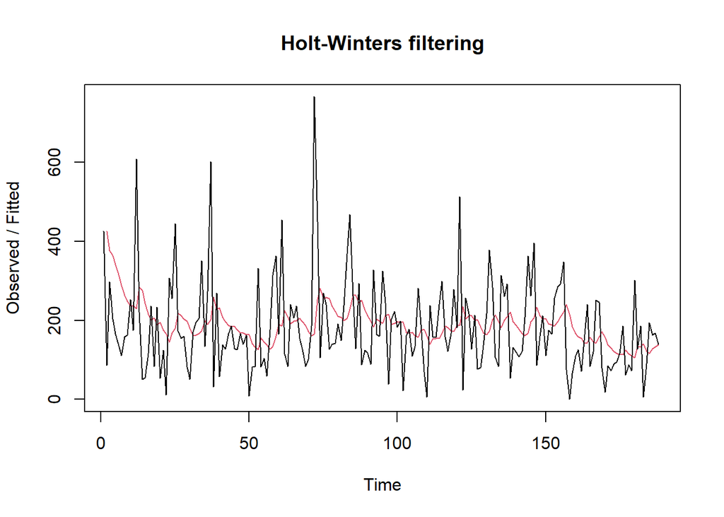

```r
plot(sesopt)
```

```r
#ramalan
ramalanopt<- forecast(sesopt, h=47)
ramalanopt
```

```
##     Point Forecast     Lo 80    Hi 80     Lo 95    Hi 95
## 189       138.3307 -20.92374 297.5852 -105.2280 381.8895
## 190       138.3307 -22.60327 299.2648 -107.7966 384.4581
## 191       138.3307 -24.26545 300.9269 -110.3387 387.0002
## 192       138.3307 -25.91081 302.5723 -112.8550 389.5165
## 193       138.3307 -27.53985 304.2013 -115.3464 392.0079
## 194       138.3307 -29.15304 305.8145 -117.8136 394.4751
## 195       138.3307 -30.75085 307.4123 -120.2572 396.9187
## 196       138.3307 -32.33369 308.9952 -122.6780 399.3395
## 197       138.3307 -33.90199 310.5635 -125.0765 401.7380
## 198       138.3307 -35.45614 312.1176 -127.4534 404.1149
## 199       138.3307 -36.99651 313.6580 -129.8092 406.4707
## 200       138.3307 -38.52347 315.1850 -132.1444 408.8059
## 201       138.3307 -40.03736 316.6988 -134.4597 411.1212
## 202       138.3307 -41.53850 318.2000 -136.7555 413.4170
```

[output cut: 33 more lines]

Setelah dilakukan peramalan, akan dilakukan perhitungan keakuratan hasil peramalan. Perhitungan akurasi ini dilakukan baik pada data latih dan data uji.

#### Akurasi Data Latih

Perhitungan akurasi data dapat dilakukan dengan cara langsung maupun manual. Secara langsung, nilai akurasi dapat diambil dari objek yang tersimpan pada hasil SES, yaitu *sum of squared errors* (SSE). Nilai akurasi lain dapat dihitung pula dari nilai SSE tersebut.

```r
#Keakuratan Metode
#Pada data training
SSE1<-ses1$SSE
MSE1<-ses1$SSE/length(train.ts)
RMSE1<-sqrt(MSE1)

akurasi1 <- matrix(c(SSE1,MSE1,RMSE1))
row.names(akurasi1)<- c("SSE", "MSE", "RMSE")
colnames(akurasi1) <- c("Akurasi lamda=0.2")
akurasi1
```

```
##      Akurasi lamda=0.2
## SSE       2913337.3872
## MSE         15496.4755
## RMSE          124.4848
```

```r
SSE2<-ses2$SSE
MSE2<-ses2$SSE/length(train.ts)
RMSE2<-sqrt(MSE2)

akurasi2 <- matrix(c(SSE2,MSE2,RMSE2))
row.names(akurasi2)<- c("SSE", "MSE", "RMSE")
colnames(akurasi2) <- c("Akurasi lamda=0.7")
akurasi2
```

```
##      Akurasi lamda=0.7
## SSE       3538455.1744
## MSE         18821.5701
## RMSE          137.1917
```

```r
#Cara Manual
fitted1<-ramalan1$fitted
sisaan1<-ramalan1$residuals
head(sisaan1)
```

```
## Time Series:
## Start = 1
## End = 6
## Frequency = 1
## [1]        NA -339.2000  -60.6600 -142.5280 -152.4224 -149.7379
```

```r
resid1<-training$total_rainfall-ramalan1$fitted
head(resid1)
```

```
## Time Series:
## Start = 1
## End = 6
## Frequency = 1
## [1]        NA -339.2000  -60.6600 -142.5280 -152.4224 -149.7379
```

```r
#Cara Manual
SSE.1=sum(sisaan1[2:length(train.ts)]^2)
SSE.1
```

```
## [1] 2913337
```

```r
MSE.1 = SSE.1/length(train.ts)
MSE.1
```

```
## [1] 15496.48
```

```r
MAPE.1 = sum(abs(sisaan1[2:length(train.ts)]/train.ts[2:length(train.ts)])*
               100)/length(train.ts)
MAPE.1
```

```
## [1] 696.6291
```

```r
akurasi.1 <- matrix(c(SSE.1,MSE.1,MAPE.1))
row.names(akurasi.1)<- c("SSE", "MSE", "MAPE")
colnames(akurasi.1) <- c("Akurasi lamda=0.2")
akurasi.1
```

```
##      Akurasi lamda=0.2
## SSE       2913337.3872
## MSE         15496.4755
## MAPE          696.6291
```

```r
fitted2<-ramalan2$fitted
sisaan2<-ramalan2$residuals
head(sisaan2)
```

```
## Time Series:
## Start = 1
## End = 6
## Frequency = 1
## [1]         NA -339.20000  108.94000  -61.31800  -56.79540  -44.83862
```

```r
resid2<-training$total_rainfall-ramalan2$fitted
head(resid2)
```

```
## Time Series:
## Start = 1
## End = 6
## Frequency = 1
## [1]         NA -339.20000  108.94000  -61.31800  -56.79540  -44.83862
```

```r
SSE.2=sum(sisaan2[2:length(train.ts)]^2)
SSE.2
```

```
## [1] 3538455
```

```r
MSE.2 = SSE.2/length(train.ts)
MSE.2
```

```
## [1] 18821.57
```

```r
MAPE.2 = sum(abs(sisaan2[2:length(train.ts)]/train.ts[2:length(train.ts)])*
               100)/length(train.ts)
MAPE.2
```

```
## [1] 525.4619
```

```r
akurasi.2 <- matrix(c(SSE.2,MSE.2,MAPE.2))
row.names(akurasi.2)<- c("SSE", "MSE", "MAPE")
colnames(akurasi.2) <- c("Akurasi lamda=0.7")
akurasi.2
```

```
##      Akurasi lamda=0.7
## SSE       3538455.1744
## MSE         18821.5701
## MAPE          525.4619
```

#### Akurasi Data Uji

Akurasi data uji dapat dihitung dengan cara yang hampir sama dengan perhitungan akurasi data latih.

```r
selisih1<-ramalan1$mean-testing$total_rainfall
SSEtesting1<-sum(selisih1^2)
MSEtesting1<-SSEtesting1/length(testing)


selisih2<-ramalan2$mean-testing$total_rainfall
SSEtesting2<-sum(selisih2^2)
MSEtesting2<-SSEtesting2/length(testing)

selisihopt<-ramalanopt$mean-testing$total_rainfall
SSEtestingopt<-sum(selisihopt^2)
MSEtestingopt<-SSEtestingopt/length(testing)

akurasitesting1 <- matrix(c(SSEtesting1,SSEtesting2,SSEtestingopt))
row.names(akurasitesting1)<- c("SSE1", "SSE2", "SSEopt")
akurasitesting1
```

```
##            [,1]
## SSE1   391834.0
## SSE2   388577.1
## SSEopt 395288.0
```

```r
akurasitesting2 <- matrix(c(MSEtesting1,MSEtesting2,MSEtestingopt))
row.names(akurasitesting2)<- c("MSE1", "MSE2", "MSEopt")
akurasitesting2
```

```
##            [,1]
## MSE1   195917.0
## MSE2   194288.5
## MSEopt 197644.0
```

## Pemulusan Data Musiman

Pertama impor kembali data baru untuk latihan data musiman.

```r
#Import data
library(rio)
data2 <- import("https://raw.githubusercontent.com/adistisucirahmah/mpdw/main/praktikum/datahujan.csv")
data2
```

```
##       month total_rainfall
## 1   2001-01          425.8
## 2   2001-02           86.6
## 3   2001-03          297.3
## 4   2001-04          203.3
## 5   2001-05          164.9
## 6   2001-06          137.1
## 7   2001-07          111.3
## 8   2001-08          158.3
## 9   2001-09          162.0
## 10  2001-10          252.2
## 11  2001-11          175.3
## 12  2001-12          609.0
## 13  2002-01          221.2
## 14  2002-02           50.8
```

[output cut: 221 more lines]

```r
data2.ts <- ts(data2$total_rainfall)
data2.ts
```

```
## Time Series:
## Start = 1
## End = 235
## Frequency = 1
##   [1] 425.8  86.6 297.3 203.3 164.9 137.1 111.3 158.3 162.0 252.2 175.3 609.0
##  [13] 221.2  50.8  55.6 116.5 236.6  83.1 233.7  54.2 124.2  10.8 307.2 255.0
##  [25] 444.2 172.9 154.6 159.9  81.8  50.3 170.4 193.6 205.3 351.4 133.8 273.0
##  [37] 600.9  31.9 269.4  57.1 137.6 127.2 166.6 185.2 128.9 125.6 166.2 139.8
##  [49] 163.2   8.4  82.4  81.7 331.1  82.3 104.0  58.5 175.7 314.5 362.9 166.0
##  [61] 454.4 115.5  83.1 239.8 205.7 236.8 153.8 127.3  83.3 102.0 185.6 765.9
##  [73] 450.1 105.5 269.1 240.2 127.2 139.0 141.7 190.7 149.0 237.2 367.9 468.6
##  [85] 262.6 129.2 294.1  87.2 124.9 118.3  89.1 327.3 164.4 159.5 324.3 244.2
##  [97]  38.3 201.8 223.3 183.7 198.6  21.8 161.0 177.8 109.6 133.4 281.8 189.8
## [109]  69.5   6.3 238.0 158.5 157.5 240.5 298.5 158.4 121.5 166.2 278.8 181.4
## [121] 513.2  23.0 256.6 217.8 127.0 213.0  76.6  81.4 136.4 216.8 377.8 284.6
## [133] 106.1  83.6 313.4 260.6 292.0  53.0 130.8 119.0 107.6 122.2 208.2 363.4
## [145] 262.0 395.2  85.8 159.4 211.4 111.4 174.6 165.6 257.0 285.4 292.4 348.2
## [157]  75.4   0.2  66.0 110.0 125.8  71.4 148.6 241.0  83.6 120.0 250.8 245.6
## [169]  79.6  18.8  84.4  73.2  89.0  95.8 116.8 185.8  61.6  87.2  72.6 302.3
## [181] 126.6 186.0   6.2  89.8 193.8 162.8 168.6 139.2 118.9 181.0 290.2 292.6
## [193] 197.6 158.4 136.2 208.6 190.0 106.0  79.6  84.2 124.4 120.8 268.6 371.2
## [205] 287.0  14.8  44.6  61.2 132.2 182.6 143.2 121.6 144.4 234.4 169.6 172.6
## [217]  63.6  31.6  72.2 174.8  69.0 173.8  12.2  11.8  22.8 176.8 137.4 421.5
## [229]  88.4  65.0 108.8 188.0 255.6 233.8 140.8
```

Selanjutnya melakukan pembagian data dan mengubahnya menjadi data deret waktu.

```r
#membagi data menjadi training dan testing
training<-data2[1:188,2]
training
```

```
##   [1] 425.8  86.6 297.3 203.3 164.9 137.1 111.3 158.3 162.0 252.2 175.3 609.0
##  [13] 221.2  50.8  55.6 116.5 236.6  83.1 233.7  54.2 124.2  10.8 307.2 255.0
##  [25] 444.2 172.9 154.6 159.9  81.8  50.3 170.4 193.6 205.3 351.4 133.8 273.0
##  [37] 600.9  31.9 269.4  57.1 137.6 127.2 166.6 185.2 128.9 125.6 166.2 139.8
##  [49] 163.2   8.4  82.4  81.7 331.1  82.3 104.0  58.5 175.7 314.5 362.9 166.0
##  [61] 454.4 115.5  83.1 239.8 205.7 236.8 153.8 127.3  83.3 102.0 185.6 765.9
##  [73] 450.1 105.5 269.1 240.2 127.2 139.0 141.7 190.7 149.0 237.2 367.9 468.6
##  [85] 262.6 129.2 294.1  87.2 124.9 118.3  89.1 327.3 164.4 159.5 324.3 244.2
##  [97]  38.3 201.8 223.3 183.7 198.6  21.8 161.0 177.8 109.6 133.4 281.8 189.8
## [109]  69.5   6.3 238.0 158.5 157.5 240.5 298.5 158.4 121.5 166.2 278.8 181.4
## [121] 513.2  23.0 256.6 217.8 127.0 213.0  76.6  81.4 136.4 216.8 377.8 284.6
## [133] 106.1  83.6 313.4 260.6 292.0  53.0 130.8 119.0 107.6 122.2 208.2 363.4
## [145] 262.0 395.2  85.8 159.4 211.4 111.4 174.6 165.6 257.0 285.4 292.4 348.2
## [157]  75.4   0.2  66.0 110.0 125.8  71.4 148.6 241.0  83.6 120.0 250.8 245.6
## [169]  79.6  18.8  84.4  73.2  89.0  95.8 116.8 185.8  61.6  87.2  72.6 302.3
## [181] 126.6 186.0   6.2  89.8 193.8 162.8 168.6 139.2
```

```r
testing<-data2[189:235,2]
testing
```

```
##  [1] 118.9 181.0 290.2 292.6 197.6 158.4 136.2 208.6 190.0 106.0  79.6  84.2
## [13] 124.4 120.8 268.6 371.2 287.0  14.8  44.6  61.2 132.2 182.6 143.2 121.6
## [25] 144.4 234.4 169.6 172.6  63.6  31.6  72.2 174.8  69.0 173.8  12.2  11.8
## [37]  22.8 176.8 137.4 421.5  88.4  65.0 108.8 188.0 255.6 233.8 140.8
```

```r
training.ts2<-ts(training, frequency = 13)
training.ts2
```

```
## Time Series:
## Start = c(1, 1)
## End = c(15, 6)
## Frequency = 13
##   [1] 425.8  86.6 297.3 203.3 164.9 137.1 111.3 158.3 162.0 252.2 175.3 609.0
##  [13] 221.2  50.8  55.6 116.5 236.6  83.1 233.7  54.2 124.2  10.8 307.2 255.0
##  [25] 444.2 172.9 154.6 159.9  81.8  50.3 170.4 193.6 205.3 351.4 133.8 273.0
##  [37] 600.9  31.9 269.4  57.1 137.6 127.2 166.6 185.2 128.9 125.6 166.2 139.8
##  [49] 163.2   8.4  82.4  81.7 331.1  82.3 104.0  58.5 175.7 314.5 362.9 166.0
##  [61] 454.4 115.5  83.1 239.8 205.7 236.8 153.8 127.3  83.3 102.0 185.6 765.9
##  [73] 450.1 105.5 269.1 240.2 127.2 139.0 141.7 190.7 149.0 237.2 367.9 468.6
##  [85] 262.6 129.2 294.1  87.2 124.9 118.3  89.1 327.3 164.4 159.5 324.3 244.2
##  [97]  38.3 201.8 223.3 183.7 198.6  21.8 161.0 177.8 109.6 133.4 281.8 189.8
## [109]  69.5   6.3 238.0 158.5 157.5 240.5 298.5 158.4 121.5 166.2 278.8 181.4
## [121] 513.2  23.0 256.6 217.8 127.0 213.0  76.6  81.4 136.4 216.8 377.8 284.6
## [133] 106.1  83.6 313.4 260.6 292.0  53.0 130.8 119.0 107.6 122.2 208.2 363.4
## [145] 262.0 395.2  85.8 159.4 211.4 111.4 174.6 165.6 257.0 285.4 292.4 348.2
## [157]  75.4   0.2  66.0 110.0 125.8  71.4 148.6 241.0  83.6 120.0 250.8 245.6
## [169]  79.6  18.8  84.4  73.2  89.0  95.8 116.8 185.8  61.6  87.2  72.6 302.3
## [181] 126.6 186.0   6.2  89.8 193.8 162.8 168.6 139.2
```

```r
testing.ts2<-ts(testing, frequency = 13)
testing.ts2
```

```
## Time Series:
## Start = c(1, 1)
## End = c(4, 8)
## Frequency = 13
##  [1] 118.9 181.0 290.2 292.6 197.6 158.4 136.2 208.6 190.0 106.0  79.6  84.2
## [13] 124.4 120.8 268.6 371.2 287.0  14.8  44.6  61.2 132.2 182.6 143.2 121.6
## [25] 144.4 234.4 169.6 172.6  63.6  31.6  72.2 174.8  69.0 173.8  12.2  11.8
## [37]  22.8 176.8 137.4 421.5  88.4  65.0 108.8 188.0 255.6 233.8 140.8
```

Kemudian akan dilakukan eskplorasi dengan plot data deret waktu sebagai berikut.

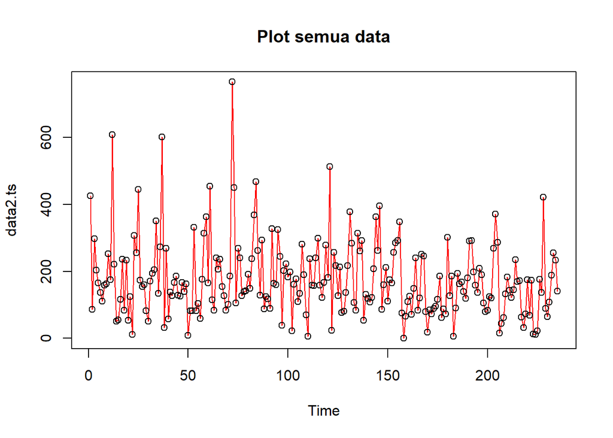

```r
#Membuat plot time series
plot(data2.ts, col="red",main="Plot semua data")
points(data2.ts)
```

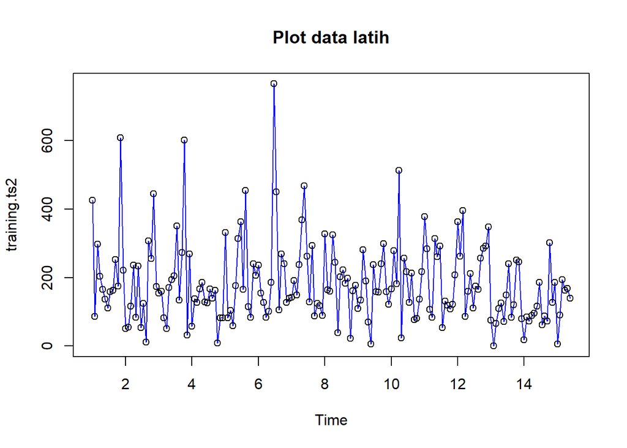

```r
plot(training.ts2, col="blue",main="Plot data latih")
points(training.ts2)
```

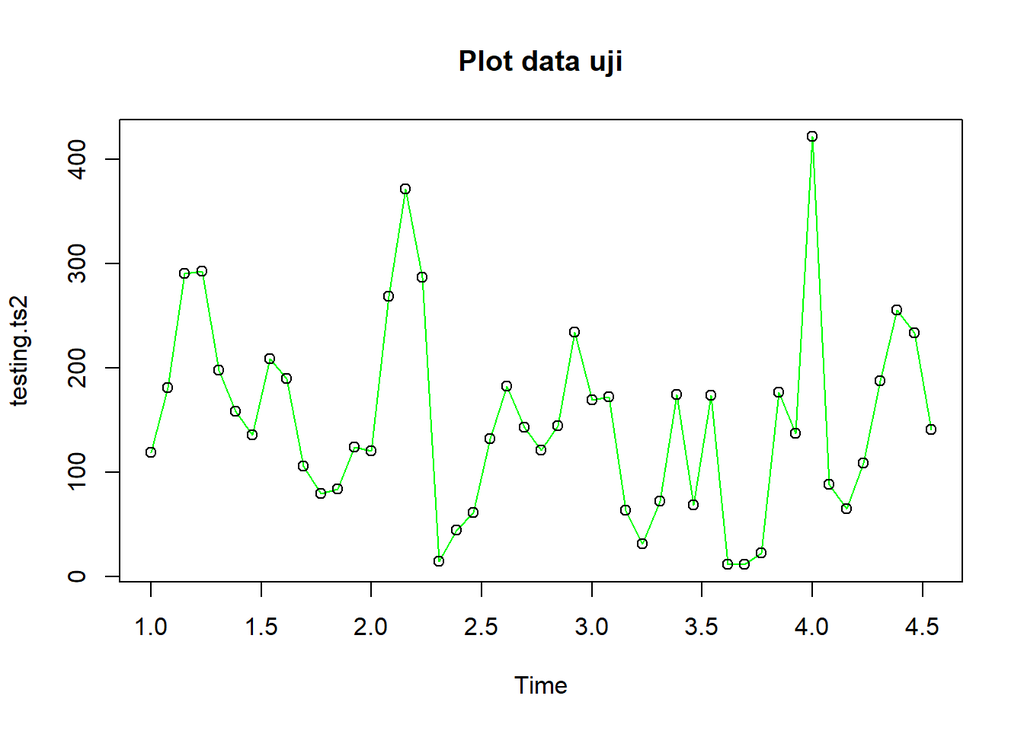

```r
plot(testing.ts2, col="green",main="Plot data uji")
points(testing.ts2)
```

Metode Holt-Winter untuk peramalan data musiman menggunakan tiga persamaan pemulusan yang terdiri atas persamaan untuk level $(L_t)$, trend $(B_t)$, dan komponen seasonal / musiman $(S_t)$ dengan parameter pemulusan berupa $\alpha$, $\beta$, dan $\gamma$. Metode Holt-Winter musiman terbagi menjadi dua, yaitu metode aditif dan metode multiplikatif. Perbedaan persamaan dan contoh datanya adalah sebagai berikut.

[figure not shown]

Pemulusan data musiman dengan metode Winter dilakukan menggunakan fungsi `HoltWinters()` dengan memasukkan argumen tambahan, yaitu `gamma()` dan `seasonal()` . Arguman `seasonal()` diinisialisasi menyesuaikan jenis musiman, aditif atau multiplikatif.

### Winter Aditif

Perhitungan dengan model aditif dilakukan jika plot data asli menunjukkan fluktuasi musiman yang relatif stabil (konstan).

#### Pemulusan

```r
#Pemulusan dengan winter aditif
winter1 <- HoltWinters(training.ts2,alpha=0.2,beta=0.1,gamma=0.1,seasonal = "additive")
winter1$fitted
```

```
## Time Series:
## Start = c(2, 1)
## End = c(15, 6)
## Frequency = 13
##                  xhat     level         trend       season
##  2.000000   72.152781 212.07168  -3.430143702 -136.4887574
##  2.076923   71.448102 204.37098  -3.857199324 -129.0656805
##  2.153846  136.635090 197.34416  -4.174161373  -56.5349112
##  2.230769  243.900439 189.14298  -4.576863169   59.3343195
##  2.307692   78.086710 183.10603  -4.722871958 -100.2964497
##  2.384615  237.743685 179.38582  -4.622606166   62.9804734
##  2.461538   51.939161 173.95447  -4.703479870 -117.3118343
##  2.538462  119.071527 169.70316  -4.658263082  -45.9733728
##  2.615385  121.626143 166.07059  -4.555693621  -39.8887574
##  2.692308  196.796390 139.34967  -6.772216487   64.2189349
##  2.769231  134.851430 154.65818  -4.564144297  -15.2426036
##  2.846154  596.712278 174.12375  -2.161172889  424.7497041
##  2.923077  165.767635 141.46012  -5.211418459   29.5189349
##  3.000000   -5.590578 137.67517  -5.068771161 -138.1969799
##  3.076923   32.446029 164.64452  -1.864959604 -130.3335287
##  3.153846  130.808754 188.27035   0.684119810  -58.1457184
##  3.230769  237.606950 179.15272  -0.296055260   58.7502844
##  3.307692   37.457695 141.39528  -4.042194267  -99.8953865
##  3.384615  225.215173 163.94154  -1.383348169   62.6569786
##  3.461538   37.088541 156.23516  -2.015651629 -117.1309672
##  3.538462  143.647283 187.86180   1.348577550  -45.5630949
##  3.615385  187.509704 230.76092   5.503631897  -48.7548489
##  3.692308  303.003274 225.52261   4.429437816   73.0512237
##  3.769231  222.150050 223.95140   3.829372344   -5.6307179
##  3.846154  727.483851 303.53076  11.404371351  412.5487219
##  3.923077  203.400577 175.81836  -2.507305666   30.0895241
##  4.000000   59.941887 186.51094  -1.187317211 -125.3817337
##  4.076923   63.373877 184.75524  -1.244154947 -120.1372110
##  4.153846  136.530262 198.35631   0.240367510  -62.0664187
##  4.230769  240.550119 196.73063   0.053762279   43.7657283
##  4.307692   91.309124 181.99437  -1.425240092  -89.2600021
##  4.384615  259.927644 199.34730   0.452577422   60.1277647
##  4.461538   67.752324 173.59435  -2.167975452 -103.6740505
##  4.538462  153.042010 182.99591  -1.011021939  -28.9428775
##  4.615385  130.816999 184.61649  -0.747862147  -53.0516252
```

[output cut: 125 more lines]

```
## 14.307692   39.577590  90.34703  -5.164428519  -45.6050164
## 14.384615  114.169337  96.42709  -4.039980318   21.7822292
## 14.461538   83.826646  92.91324  -3.987367062   -5.0992277
## 14.538462   82.289707 109.32054  -1.947899979  -25.0829370
## 14.615385   62.240747 103.23470  -2.361694128  -38.6322621
## 14.692308  106.719204 105.86486  -1.862509060    2.7168538
## 14.769231   84.659550  97.17851  -2.544893145   -9.9740667
## 14.846154  284.293121 138.16171   1.807915861  144.3234988
## 14.923077  139.618431 108.43100  -1.345946562   32.5333794
## 15.000000   98.225284 116.36137  -0.418315181  -17.7177664
## 15.076923   47.729309  97.53799  -2.258820855  -47.5498633
## 15.153846   70.822080 103.69331  -1.417407040  -31.4538235
## 15.230769  140.735502 126.87149   1.042151357   12.8218625
## 15.307692   92.702756 132.32654   1.483441326  -41.1072236
## 15.384615  173.983497 148.98943   3.001386198   21.9926822
```

```r
xhat1 <- winter1$fitted[,2]

winter1.opt<- HoltWinters(training.ts2, alpha= NULL,  beta = NULL, gamma = NULL, seasonal = "additive")
winter1.opt
```

```
## Holt-Winters exponential smoothing with trend and additive seasonal component.
##
## Call:
## HoltWinters(x = training.ts2, alpha = NULL, beta = NULL, gamma = NULL,     seasonal = "additive")
##
## Smoothing parameters:
##  alpha: 0.0586037
##  beta : 0.02932767
##  gamma: 0.3609178
##
## Coefficients:
##            [,1]
## a    89.8546244
## b    -0.8027511
## s1   70.7110790
## s2   21.6045332
## s3    6.9303960
## s4   16.9337220
## s5  126.8082300
## s6   66.0747740
## s7   67.4948116
## s8  -17.9784134
## s9    4.7066850
## s10  50.2254225
## s11  33.4215853
## s12  38.4446636
## s13  34.0239021
```

```r
winter1.opt$fitted
```

```
## Time Series:
## Start = c(2, 1)
## End = c(15, 6)
## Frequency = 13
##                  xhat     level         trend       season
##  2.000000  72.1527811 212.07168 -3.4301437025 -136.4887574
##  2.076923  74.8576631 207.39019 -3.4668429434 -129.0656805
##  2.153846 142.7599208 202.79477 -3.4999412840  -56.5349112
##  2.230769 253.5451487 197.75590 -3.5450744758   59.3343195
##  2.307692  89.3471328 193.21778 -3.5741982744 -100.2964497
##  2.384615 248.6730155 189.27748 -3.5849352848   62.9804734
##  2.461538  63.8925642 184.81507 -3.6106695582 -117.3118343
##  2.538462 131.0356774 180.63638 -3.6273282665  -45.9733728
##  2.615385 133.0806200 176.60845 -3.6390768145  -39.8887574
##  2.692308 226.1729742 165.80328 -3.8492417540   64.2189349
##  2.769231 147.7499392 166.70252 -3.7099797845  -15.2426036
##  2.846154 590.5018489 169.27779 -3.5256480193  424.7497041
##  2.923077 182.9201520 157.17832 -3.7770984880   29.5189349
##  3.000000   5.2759581 152.81400 -3.7943202247 -143.7437208
##  3.076923  18.6241517 157.77062 -3.5376754823 -135.6087926
##  3.153846  93.7602108 162.51223 -3.2948632516  -65.4571572
##  3.230769 208.7779588 158.51646 -3.3154193870   53.5769227
##  3.307692  39.9068275 145.91364 -3.5877970592 -102.4190172
##  3.384615 204.5028516 149.97323 -3.3635171226   57.8931417
##  3.461538  21.9834619 145.97076 -3.3822559641 -120.6050446
##  3.538462 101.9684372 153.33153 -3.0671879743  -48.2959082
##  3.615385  80.8078327 164.88196 -2.6384874223  -81.4356369
##  3.692308 254.5508152 165.34901 -2.5474092480   91.7492179
##  3.769231 182.5644801 163.88279 -2.5157004473   21.1973928
##  3.846154 559.1276039 185.88310 -1.7967029543  375.0412116
##  3.923077 176.6004725 153.18891 -2.7028543744   26.1144212
##  4.000000  60.3726999 155.92445 -2.5433588870  -93.0083878
##  4.076923  63.0323441 153.18930 -2.5489837095  -87.6079676
##  4.153846  83.0685903 155.01025 -2.4208235245  -69.5208382
##  4.230769 152.5621117 155.17569 -2.3449744238   -0.2686062
##  4.307692  93.2507565 153.65339 -2.3208473630  -58.0817861
##  4.384615 208.7470110 156.72111 -2.1628132674   54.1887161
##  4.461538  89.2587235 149.87896 -2.3000471335  -58.3201943
##  4.538462 183.9236881 149.70865 -2.2375870136   36.4526242
##  4.615385  80.7336769 146.43239 -2.2680488958  -63.4306645
```

[output cut: 125 more lines]

```
## 14.307692 112.5285782  92.76880 -1.2443345567   21.0041172
## 14.384615 113.5317789  90.54410 -1.2730861334   24.2607606
## 14.461538 145.0661552  89.46255 -1.2674690087   56.8710761
## 14.538462 136.4058374  90.58223 -1.1974593373   47.0210638
## 14.615385  92.3576344  85.00088 -1.3260288874    8.6827882
## 14.692308 112.5425737  83.37259 -1.3348933658   30.5048774
## 14.769231 155.0817436  79.69691 -1.4035430716   76.7883728
## 14.846154 164.8367268  86.92090 -1.1505175640   79.0663395
## 14.923077 131.1832426  83.52957 -1.2162354134   48.8699043
## 15.000000  97.4183101  85.52580 -1.1220212976   13.0145284
## 15.076923  78.7220033  79.05805 -1.2787991305    0.9427510
## 15.153846  93.2205984  78.42846 -1.2597592655   16.0518938
## 15.230769  91.0037488  83.06303 -1.0868924298    9.0276119
## 15.307692 100.5404711  86.18366 -0.9634954862   15.3203039
## 15.384615 113.7333795  89.20871 -0.8465208848   25.3711932
```

```r
xhat1.opt <- winter1.opt$fitted[,2]
```

#### Peramalan

```r
#Forecast
forecast1 <- predict(winter1, n.ahead = 47)
forecast1.opt <- predict(winter1.opt, n.ahead = 47)
```

#### Plot Deret Waktu

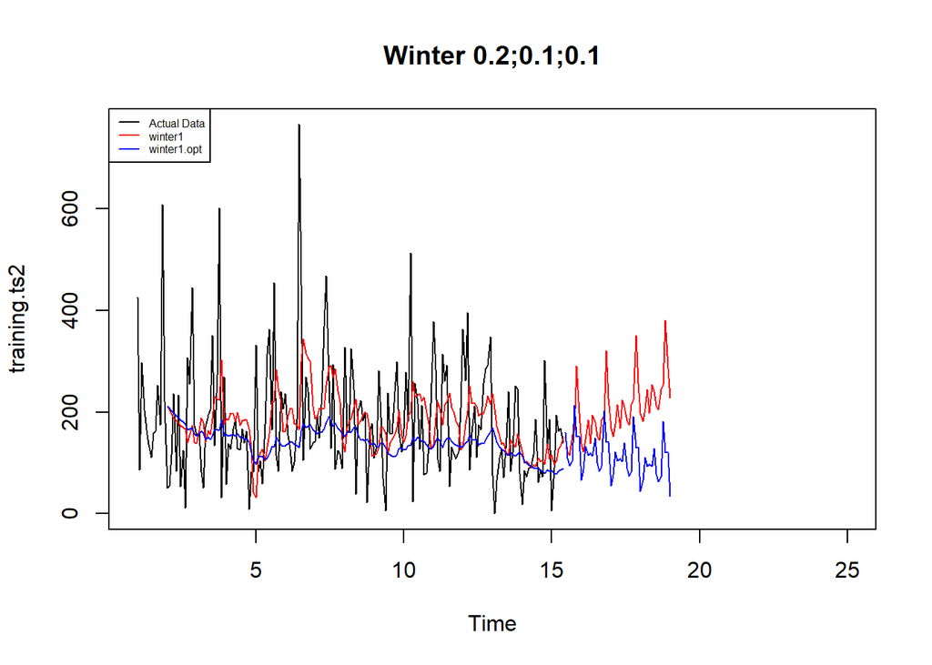

```r
#Plot time series
plot(training.ts2,main="Winter 0.2;0.1;0.1",type="l",col="black",
     xlim=c(1,25),pch=12)
lines(xhat1,type="l",col="red")
lines(xhat1.opt,type="l",col="blue")
lines(forecast1,type="l",col="red")
lines(forecast1.opt,type="l",col="blue")
legend("topleft",c("Actual Data",expression(paste(winter1)),
                   expression(paste(winter1.opt))),cex=0.5,
       col=c("black","red","blue"),lty=1)
```

#### Akurasi Data Latih

```r
#Akurasi data training
SSE1<-winter1$SSE
MSE1<-winter1$SSE/length(training.ts2)
RMSE1<-sqrt(MSE1)
akurasi1 <- matrix(c(SSE1,MSE1,RMSE1))
row.names(akurasi1)<- c("SSE", "MSE", "RMSE")
colnames(akurasi1) <- c("Akurasi")
akurasi1
```

```
##           Akurasi
## SSE  4469345.1452
## MSE    23773.1125
## RMSE     154.1853
```

```r
SSE1.opt<-winter1.opt$SSE
MSE1.opt<-winter1.opt$SSE/length(training.ts2)
RMSE1.opt<-sqrt(MSE1.opt)
akurasi1.opt <- matrix(c(SSE1.opt,MSE1.opt,RMSE1.opt))
row.names(akurasi1.opt)<- c("SSE1.opt", "MSE1.opt", "RMSE1.opt")
colnames(akurasi1.opt) <- c("Akurasi")
akurasi1.opt
```

```
##                Akurasi
## SSE1.opt  3237432.5449
## MSE1.opt    17220.3859
## RMSE1.opt     131.2265
```

```r
akurasi1.train = data.frame(Model_Winter = c("Winter 1","Winter1 optimal"),
                            Nilai_SSE=c(SSE1,SSE1.opt),
                            Nilai_MSE=c(MSE1,MSE1.opt),Nilai_RMSE=c(RMSE1,RMSE1.opt))
akurasi1.train
```

```
##      Model_Winter Nilai_SSE Nilai_MSE Nilai_RMSE
## 1        Winter 1   4469345  23773.11   154.1853
## 2 Winter1 optimal   3237433  17220.39   131.2265
```

#### Akurasi Data Uji

```r
#Akurasi Data Testing
forecast1<-data.frame(forecast1)
testing.ts2<-data.frame(testing.ts2)
selisih1<-forecast1-testing.ts2
SSEtesting1<-sum(selisih1^2)
MSEtesting1<-SSEtesting1/length(testing.ts2)

forecast1.opt<-data.frame(forecast1.opt)
selisih1.opt<-forecast1.opt-testing.ts2
SSEtesting1.opt<-sum(selisih1.opt^2)
MSEtesting1.opt<-SSEtesting1.opt/length(testing.ts2)
```

### Winter Multiplikatif

Model multiplikatif digunakan cocok digunakan jika plot data asli menunjukkan fluktuasi musiman yang bervariasi.

#### Pemulusan

```r
#Pemulusan dengan winter multiplikatif
winter2 <- HoltWinters(training.ts2,alpha=0.2,beta=0.1,gamma=0.3,seasonal = "multiplicative")
winter2$fitted
```

```
## Time Series:
## Start = c(2, 1)
## End = c(15, 6)
## Frequency = 13
##                 xhat    level        trend    season
##  2.000000   56.14643 212.0717  -3.43014370 0.2691048
##  2.076923   60.00351 204.6680  -3.82749317 0.2987619
##  2.153846  129.55054 197.8927  -4.12227687 0.6685774
##  2.230769  245.60018 189.8665  -4.51267418 1.3250346
##  2.307692   80.64428 183.9953  -4.64852244 0.4496556
##  2.384615  239.14970 180.4391  -4.53929564 1.3595795
##  2.461538   67.77242 175.0981  -4.61946307 0.3975421
##  2.538462  121.63488 163.6504  -5.30228007 0.7681483
##  2.615385  122.32957 159.0160  -5.23549306 0.7954814
##  2.692308  156.66073 125.7398  -8.03957031 1.3310149
##  2.769231  122.78324 140.3204  -5.77754797 0.9125956
##  2.846154  526.87465 163.5189  -2.87994990 3.2798694
##  2.923077  174.22881 155.5976  -3.38408369 1.1446345
##  3.000000   39.05050 151.9813  -3.40730170 0.2628354
##  3.076923   70.97413 236.4994   5.38523591 0.2934214
##  3.153846  204.71705 302.4977  11.44654280 0.6520809
##  3.230769  372.87180 276.2443   7.67654917 1.3132949
##  3.307692  107.59655 234.7968   2.76414456 0.4529219
##  3.384615  366.19314 265.2935   5.53740206 1.3521098
##  3.461538   93.76209 245.3015   2.98445646 0.3776376
##  3.538462  244.15044 307.3573   8.89159702 0.7720198
##  3.615385  207.23422 344.0331  11.67001177 0.5826045
##  3.692308  539.52091 330.4941   9.14911754 1.5884929
##  3.769231  345.14320 306.0868   5.79347262 1.1066529
##  3.846154 1161.69599 358.1020  10.41564107 3.1523487
##  3.923077  342.85869 296.8380   3.24767775 1.1425361
##  4.000000  109.91919 287.2268   1.96178947 0.3800952
##  4.076923   94.84398 261.3959  -0.81747129 0.3639747
##  4.153846  155.73750 284.0724   1.53192365 0.5452911
##  4.230769  271.09553 275.1375   0.48523483 0.9835748
##  4.307692  128.82852 254.3746  -1.63957635 0.5097376
##  4.384615  325.89580 274.8529   0.57220793 1.1832467
##  4.461538  111.24290 242.1276  -2.75754229 0.4647320
##  4.538462  206.12797 245.5487  -2.13967625 0.8468379
##  4.615385  122.20832 233.9791  -3.08266587 0.5292777
```

[output cut: 125 more lines]

```
## 14.307692   79.94710 157.9006  -8.33489778 0.5345282
## 14.384615   79.55743 155.4973  -7.74174312 0.5384396
## 14.461538  110.40659 161.5891  -6.35839136 0.7112421
## 14.538462  112.91541 176.4312  -4.23834218 0.6557499
## 14.615385   78.23944 156.5419  -5.80343327 0.5190409
## 14.692308   91.22394 154.1912  -5.45815942 0.6133401
## 14.769231   94.32662 142.6601  -6.06545509 0.6905588
## 14.846154  146.31489 196.8280  -0.04211876 0.7435233
## 14.923077  121.16358 191.4828  -0.57242861 0.6346622
## 15.000000  117.59665 211.3421   1.47075044 0.5525824
## 15.076923   86.52546 172.4943  -2.56110647 0.5091733
## 15.153846   88.49032 171.2194  -2.43248453 0.5242723
## 15.230769  115.54807 208.9606   1.58488144 0.5488033
## 15.307692  129.16856 227.7655   3.30688024 0.5589961
## 15.384615  148.37795 245.1803   4.71767500 0.5937541
```

```r
xhat2 <- winter2$fitted[,2]

winter2.opt<- HoltWinters(training.ts2, alpha= NULL,  beta = NULL, gamma = NULL, seasonal = "multiplicative")
winter2.opt$fitted
```

```
## Time Series:
## Start = c(2, 1)
## End = c(15, 6)
## Frequency = 13
##                xhat     level      trend    season
##  2.000000  56.14643 212.07168 -3.4301437 0.2691048
##  2.076923  61.19768 208.27721 -3.4395941 0.2987619
##  2.153846 134.41450 204.49403 -3.4485065 0.6685774
##  2.230769 261.15491 200.55415 -3.4612521 1.3250346
##  2.307692  86.91077 196.75307 -3.4700671 0.4496556
##  2.384615 257.84899 193.12759 -3.4740984 1.3595795
##  2.461538  73.88129 189.32776 -3.4825474 0.3975421
##  2.538462 139.36611 184.93734 -3.5060968 0.7681483
##  2.615385 141.24067 181.06918 -3.5154883 0.7954814
##  2.692308 227.54123 174.54667 -3.5934879 1.3310149
##  2.769231 153.75927 172.05068 -3.5650197 0.9125956
##  2.846154 547.76374 170.52004 -3.5122498 3.2798694
##  2.923077 186.46266 166.42875 -3.5272695 1.1446345
##  3.000000  41.65907 162.68420 -3.5329057 0.2617577
##  3.076923  47.63526 167.06366 -3.3276661 0.2909273
##  3.153846 107.81261 170.81240 -3.1441102 0.6430113
##  3.230769 211.14217 166.92644 -3.1633532 1.2893148
##  3.307692  70.26547 161.47540 -3.2226936 0.4440080
##  3.384615 210.72968 162.38840 -3.1154177 1.3230724
##  3.461538  57.23332 159.03556 -3.1215762 0.3670827
##  3.538462 119.35169 163.31085 -2.9297080 0.7441754
##  3.615385  94.98405 166.09931 -2.7813837 0.5815898
##  3.692308 236.78794 164.54183 -2.7496367 1.4635313
##  3.769231 172.67169 162.24594 -2.7378671 1.0825264
##  3.846154 509.34910 166.76230 -2.5496989 3.1017663
##  3.923077 177.94174 161.38985 -2.6229185 1.1207733
##  4.000000  71.78334 160.26337 -2.5841021 0.4552491
##  4.076923  74.00597 157.08780 -2.5994442 0.4790391
##  4.153846  92.38637 156.92280 -2.5362970 0.5984096
##  4.230769 153.59051 155.45336 -2.5086237 1.0042223
##  4.307692  93.49660 153.18230 -2.5024614 0.6204984
##  4.384615 195.07444 153.39003 -2.4321616 1.2922443
##  4.461538  92.45971 150.01879 -2.4565204 0.6265810
##  4.538462 167.14381 148.53218 -2.4313617 1.1440306
##  4.615385  93.24705 146.08569 -2.4317541 0.6491089
```

[output cut: 125 more lines]

```
## 14.307692 137.22800 100.54626 -0.4584622 1.3710763
## 14.384615 140.90302  99.53370 -0.4728350 1.4223884
## 14.461538 168.61064  98.75011 -0.4808955 1.7158032
## 14.538462 151.46052  98.45293 -0.4761301 1.5458814
## 14.615385 122.86418  96.91083 -0.5037805 1.2744315
## 14.692308 136.02966  95.89387 -0.5170920 1.4262346
## 14.769231 166.23768  94.56122 -0.5382469 1.7680539
## 14.846154 172.74186  95.43420 -0.5016409 1.8196272
## 14.923077 149.94326  94.46754 -0.5137030 1.5959248
## 15.000000 128.64346  94.36815 -0.5029561 1.3705129
## 15.076923 111.39702  92.22684 -0.5454534 1.2150450
## 15.153846 118.00250  91.35544 -0.5539084 1.2995651
## 15.230769 113.73785  91.87110 -0.5261646 1.2451467
## 15.307692 114.62844  92.06751 -0.5074217 1.2519477
## 15.384615 124.24834  92.35064 -0.4869154 1.3525288
```

```r
xhat2.opt <- winter2.opt$fitted[,2]
```

#### Peramalan

```r
#Forecast
forecast2 <- predict(winter2, n.ahead = 47)
forecast2.opt <- predict(winter2.opt, n.ahead = 47)
```

#### Plot Deret Waktu

[figure not shown]

```r
#Plot time series
plot(training.ts2,main="Winter 0.2;0.1;0.1",type="l",col="black",
     xlim=c(1,25),pch=12)
lines(xhat2,type="l",col="red")
lines(xhat2.opt,type="l",col="blue")
lines(forecast2,type="l",col="red")
lines(forecast2.opt,type="l",col="blue")
legend("topleft",c("Actual Data",expression(paste(winter2)),
                   expression(paste(winter2.opt))),cex=0.5,
       col=c("black","red","blue"),lty=1)
```

#### Akurasi Data Latih

```r
#Akurasi data training
SSE2<-winter2$SSE
MSE2<-winter2$SSE/length(training.ts2)
RMSE2<-sqrt(MSE2)
akurasi1 <- matrix(c(SSE2,MSE2,RMSE2))
row.names(akurasi1)<- c("SSE2", "MSE2", "RMSE2")
colnames(akurasi1) <- c("Akurasi lamda=0.2")
akurasi1
```

```
##       Akurasi lamda=0.2
## SSE2       4983124.5838
## MSE2         26505.9818
## RMSE2          162.8066
```

```r
SSE2.opt<-winter2.opt$SSE
MSE2.opt<-winter2.opt$SSE/length(training.ts2)
RMSE2.opt<-sqrt(MSE2.opt)
akurasi1.opt <- matrix(c(SSE2.opt,MSE2.opt,RMSE2.opt))
row.names(akurasi1.opt)<- c("SSE2.opt", "MSE2.opt", "RMSE2.opt")
colnames(akurasi1.opt) <- c("Akurasi")
akurasi1.opt
```

```
##                Akurasi
## SSE2.opt  3004756.7403
## MSE2.opt    15982.7486
## RMSE2.opt     126.4229
```

```r
akurasi2.train = data.frame(Model_Winter = c("Winter 1","winter2 optimal"),
                            Nilai_SSE=c(SSE2,SSE2.opt),
                            Nilai_MSE=c(MSE2,MSE2.opt),Nilai_RMSE=c(RMSE2,RMSE2.opt))
akurasi2.train
```

```
##      Model_Winter Nilai_SSE Nilai_MSE Nilai_RMSE
## 1        Winter 1   4983125  26505.98   162.8066
## 2 winter2 optimal   3004757  15982.75   126.4229
```

#### Akurasi Data Uji

```r
#Akurasi Data Testing
forecast2<-data.frame(forecast2)
testing.ts2<-data.frame(testing.ts2)
selisih2<-forecast2-testing.ts2
SSEtesting2<-sum(selisih2^2)
MSEtesting2<-SSEtesting2/length(testing.ts2)

forecast2.opt<-data.frame(forecast2.opt)
selisih2.opt<-forecast2.opt-testing.ts2
SSEtesting2.opt<-sum(selisih2.opt^2)
MSEtesting2.opt<-SSEtesting2.opt/length(testing.ts2)
```